# Week 4: Advanced Sampling and Variance Reduction

STAT 536 — Statistical Computing

Soumojit Das

Fall 2026

# Ratio of Uniforms

## Beyond Accept-Reject: Motivation

**Recall: Accept-Reject Challenges.**

- Finding good proposal $g(x)$ can be difficult
- Computing $M = \sup_x \frac{f(x)}{g(x)}$ may be hard
- Efficiency $1/M$ can be poor

Recall how much work last week went into choosing $g$ and computing the optimal $M$? Ratio of uniforms sidesteps both.

**Ratio of Uniforms: A Different Approach.** Instead of sampling from $X$ directly:

1. Sample $(U, V)$ uniformly from a 2D region
2. Transform to get $X = V/U$
3. Automatic normalization.

**Key Advantage.** Works directly with **unnormalized** densities without finding normalizing constants.

## Ratio of Uniforms: The Theorem

**Theorem (Kinderman-Monahan, 1977).** Let $f(x) \geq 0$ be a density (possibly unnormalized). Define region:
$$\mathcal{R}_f = \left\{(u,v): 0 \leq u \leq \sqrt{f(v/u)}\right\}$$

If $(U,V) \sim \Uniform(\mathcal{R}_f)$, then $X = V/U$ has density proportional to $f$.

In words: scatter points uniformly on a region in the $(u,v)$ plane defined by $f$, then read off $X = V/U$. The transformation from uniform samples to the target happens through the geometry of the region.

## Ratio of Uniforms: Derivation

**Change of variables.** $(u,v) \to (u, x)$ where $x = v/u$, so $v = ux$.

**Jacobian.** $\dfrac{\partial(u,v)}{\partial(u,x)} = \begin{pmatrix} 1 & 0 \\ x & u \end{pmatrix}$, so $|J| = u$.

**Joint density of $(U,X)$.** Since $(U,V)$ is uniform on $\mathcal{R}_f$:
$$p(u,x) = \frac{u}{|\mathcal{R}_f|} \cdot \mathbf{1}\left[0 \leq u \leq \sqrt{f(x)}\right]$$

**Marginal of $X$:**
$$p(x) = \int_0^{\sqrt{f(x)}} \frac{u}{|\mathcal{R}_f|} \, du = \frac{1}{|\mathcal{R}_f|} \cdot \frac{f(x)}{2} \propto f(x) \qquad \square$$

## Finding the Bounding Rectangle

**The Challenge.** We need to sample uniformly from $\mathcal{R}_f$. Solution: find a rectangle containing $\mathcal{R}_f$.

**Bounds Needed.**

$$\begin{aligned}
a^+ &= \sup_{x} \sqrt{f(x)} \\
b^- &= \inf_{x}\; x\sqrt{f(x)} \\
b^+ &= \sup_{x}\; x\sqrt{f(x)}
\end{aligned}$$

**Rectangle.** Sample $(U,V)$ uniformly from $[0, a^+] \times [b^-, b^+]$.

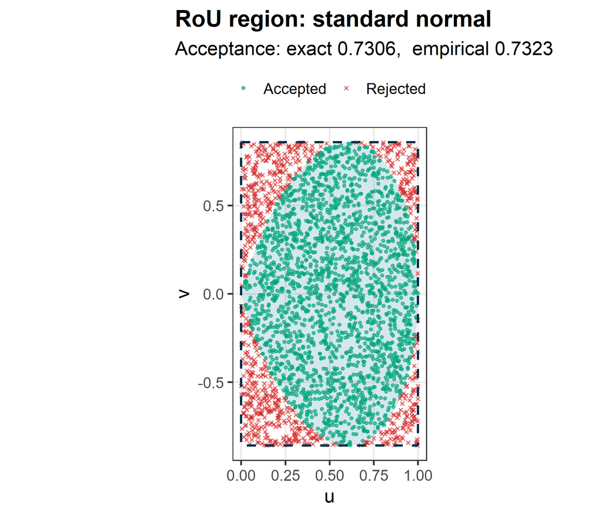

## Ratio of Uniforms: Algorithm

**Algorithm.**

1. Generate $U \sim \Uniform(0, a^+)$
2. Generate $V \sim \Uniform(b^-, b^+)$
3. Set $X \leftarrow V/U$
4. Accept if $U^2 \leq f(X)$; otherwise return to step 1

**Example: Standard Normal.** For $f(x) = \exp(-x^2/2)$:

- $a^+ = \sqrt{f(0)} = 1$
- $b^- = -\sqrt{2/e}$ (solve $\frac{d}{dx}[x \exp(-x^2/4)] = 0$)
- $b^+ = +\sqrt{2/e}$

## Ratio of Uniforms: Examples

**Example 1: Gamma Distribution.** For $\Gam(\alpha, 1)$, $\alpha \geq 1$, with $f(x) = x^{\alpha-1}e^{-x}$:

- $a^+ = \left(\frac{\alpha-1}{e}\right)^{(\alpha-1)/2}$
- $b^- = 0$
- $b^+ = \left(\frac{\alpha+1}{e}\right)^{(\alpha+1)/2}$

**Example 2: Student’s $t$.** For the $t_\nu$ distribution:

- Bounds depend on $\nu$
- Efficient for heavy tails.

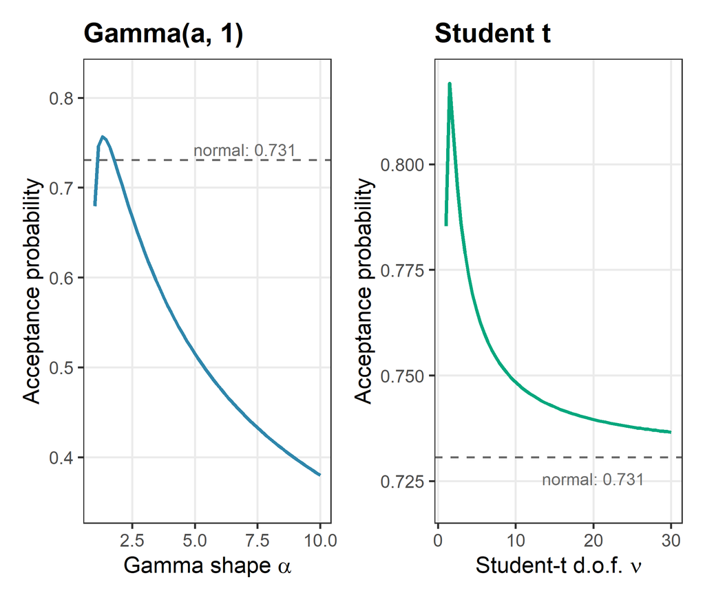

# Adaptive Rejection Sampling

## ARS: The Problem

**Recall: Accept-Reject Challenges.** For complex distributions, finding a good proposal $g$ is hard.

- Too loose: poor efficiency
- Too tight: difficult to sample from
- Fixed envelope: can’t improve

**The ARS Innovation (Gilks & Wild, 1992).** What if rejected points could **improve** our envelope?

- Build envelope that gets tighter with each rejection
- Turn “failures” into information
- Achieve near-perfect efficiency as sampling proceeds

## Log-Concavity

**Definition.** A density $f$ is **log-concave** if $\log f$ is concave:
$$\log f(\lambda x + (1-\lambda)y) \geq \lambda \log f(x) + (1-\lambda)\log f(y)$$

**Log-Concave Distributions.**

- Normal (any $\mu, \sigma^2$)
- Exponential, Laplace
- Gamma ($\alpha \geq 1$)
- Beta ($\alpha, \beta \geq 1$)
- Uniform (trivially)
- Chi-squared ($\nu \geq 2$)

**Why Log-Concavity Matters.** In log space:

- **Tangents**: upper bounds
- **Chords**: lower bounds
- **Piecewise linear**: easy to construct

In original space:

- **Piecewise exponential**: still easy to sample.

## Building Adaptive Envelopes

**Building Adaptive Envelopes in Log Space.**

1. Start with a few evaluation points
2. Draw tangent lines at these points (always above due to concavity)
3. Take the **minimum** of all tangents: upper hull
4. Connect adjacent points with straight lines: lower hull

**The Sandwich Property.**
$$\text{Lower hull} \leq \log f(x) \leq \text{Upper hull}$$
Exponentiating: $\exp(\text{Lower hull}) \leq f(x) \leq \exp(\text{Upper hull})$

**The Adaptive Part.** When we reject a point $x^*$, we have already evaluated $f(x^*)$. Add $x^*$ as a new support point: the upper hull gets tighter at $x^*$, the envelope improves, and future efficiency increases.

## ARS: Initial Envelope

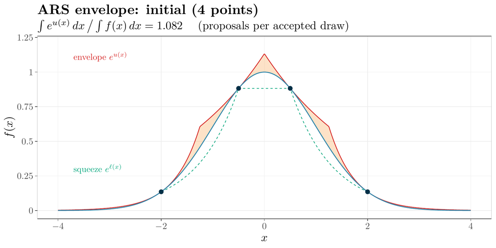

- **4 initial points**: Tangents create loose upper hull
- **Shaded region**: Gap between upper and lower bounds
- **Efficiency**: Proportional to gap area (smaller is better)

## ARS: After Adaptation

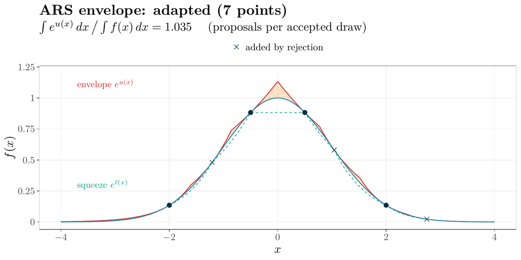

- **7 support points**: Added 3 rejected samples
- **Tighter envelope**: Shaded region much smaller
- **Higher efficiency**: proposals per accepted draw fall from 1.08 to 1.04; each rejection improved the envelope for good

## ARS: The Algorithm (Setup)

**Initialization.**

1. **Require:** Initial points $S = \{x_1, \ldots, x_k\}$, target $\log f$
2. Compute $h_i = \log f(x_i)$ for all $x_i \in S$
3. Build upper hull $u(x)$ from tangents at $S$
4. Build lower hull $\ell(x)$ from chords between adjacent points

**Key Components.**

- **Upper hull**: Piecewise linear (tangents) in log space
- **Lower hull**: Piecewise linear (chords) in log space
- **Proposal**: $\exp(u(x))/Z$ is piecewise exponential

## ARS: The Algorithm (Sampling Loop)

**Sampling.**

1. Sample $X \sim \exp(u(x))/Z$ where $Z = \int \exp(u(x))dx$
2. Generate $U \sim \Uniform(0,1)$
3. If $U \leq \exp(\ell(X) - u(X))$: **squeeze accept** (no $f$ evaluation needed)
4. Else compute $h_X = \log f(X)$ (expensive step)
   - If $U \leq \exp(h_X - u(X))$: **accept**
   - Else **reject and adapt**: $S \leftarrow S \cup \{X\}$, update hulls

## ARS: Three Types of Outcomes

1. **Squeeze Accept (best case).** Test: $U \leq \exp(\ell(X) - u(X))$. No evaluation of $f(X)$ needed. Frequency increases as envelope tightens. Computational cost: $O(1)$.
2. **Normal Accept.** Test: $U \leq \exp(\log f(X) - u(X)) = f(X)/\text{envelope}(X)$. Requires one evaluation of $f(X)$. Standard accept-reject step. Computational cost: $O(1) +$ cost of $f$.
3. **Reject and Adapt.** Sample rejected but not wasted. Add $X$ to support points. Update hulls: $O(\log k)$ for $k$ points. Future sampling more efficient.

## ARS: Advantages and Extensions

**Advantages.**

- **Self-improving**: Gets better as it runs
- **Minimal setup**: Just 2-3 initial points
- **Squeeze property**: Saves expensive evaluations
- **Guaranteed convergence**: Envelope approaches target

**When to Use ARS.**

- Log-concave target
- Expensive $f$ evaluations
- Need many samples
- Unknown normalization OK

**Implementation Tips.**

- **Data structure**: Sorted list of $(x_i, h_i, h'_i)$
- **Sampling**: Exponential pieces via inversion
- **Binary search**: Find piece in $O(\log k)$
- **Numerical**: Work in log space always

**Extensions.**

- **ARMS**: Metropolis step for non-log-concave
- **Transformed ARS**: $T(X)$ where $T(\cdot)$ makes log-concave
- **Multivariate**: Possible but complex

# Monte Carlo Integration

## Monte Carlo Integration: A Recap

**The Problem.** Evaluate: $I = \int_{\mathcal{X}} h(x) f(x) dx = \E_f[h(X)]$

**Basic Monte Carlo.** Sample $X_1, \ldots, X_n \iid f$, estimate $\hat{I}_n = \frac{1}{n}\sum_{i=1}^n h(X_i)$.

- $\E[\hat{I}_n] = I$ (unbiased)
- $\Var[\hat{I}_n] = \frac{\Var_f[h(X)]}{n}$
- $\hat{I}_n \xrightarrow{a.s.} I$ (SLLN)
- $\sqrt{n}(\hat{I}_n - I) \xrightarrow{d} \Normal(0, \Var_f[h(X)])$

Recall the $n^{-1/2}$ rate from week 1? It is dimension-free: the same rate in one dimension and in a million. Everything that follows is about pushing the constant in front of $n^{-1/2}$ down.

**Error Rate.** Standard error: $O(n^{-1/2})$, independent of dimension. Compare: Riemann sums $O(n^{-1/d})$.

## Importance Sampling

**The Importance Sampling Identity**

$$I = \int h(x)f(x)dx = \int h(x)\frac{f(x)}{g(x)}g(x)dx = \E_g\left[h(X)\frac{f(X)}{g(X)}\right]$$

**Algorithm.**

1. Sample $X_1, \ldots, X_n \iid g$
2. Compute weights $w_i = \frac{f(X_i)}{g(X_i)}$
3. Estimate: $\hat{I}_{IS} = \frac{1}{n}\sum_{i=1}^n h(X_i)w_i$

Instead of sampling from the target $f$ and averaging $h$, sample from a proposal $g$ you can draw from and reweight each draw by $f/g$. Every draw is kept; none are rejected.

## Importance Sampling: Unbiasedness and Variance

**Unbiasedness.**
$$\E_g[\hat{I}_{IS}] = \E_g\left[h(X)\frac{f(X)}{g(X)}\right] = \int h(x)\frac{f(x)}{g(x)}g(x)dx = \int h(x)f(x)dx = I$$

**Variance.**
$$\Var_g[\hat{I}_{IS}] = \frac{1}{n}\Var_g\left[h(X)\frac{f(X)}{g(X)}\right] = \frac{1}{n}\left(\int \frac{h(x)^2 f(x)^2}{g(x)} dx - I^2\right)$$

The variance depends on the match between $g$ and $|h|f$: where $g$ underweights regions that matter for $hf$, the importance weights blow up and the variance grows.

**Finite-variance condition.** The estimator has finite variance when $\int \frac{h(x)^2 f(x)^2}{g(x)} dx < \infty$.

## Importance Sampling: Optimal Proposal

**Optimal Proposal.** Minimum variance when:
$$g^*(x) \propto |h(x)|f(x)$$

Zero variance if $h \geq 0$. But $g^*$ requires knowing $\int |h(x)|f(x)dx$, which is the integral you are trying to compute.

**Weight Degeneracy**

When $g$ has thinner tails than $f$, a few weights dominate the sum. The effective sample size collapses; the running estimate sits at a plateau that looks converged, usually too low, until a single large weight arrives and moves it. The estimator stays consistent, but its error is heavy-tailed and no finite $n$ is safe. High dimensions make this worse: for a fixed mismatch between $g$ and $f$, the largest weight’s share of the total grows exponentially with the dimension.

## Self-Normalized Importance Sampling

**When $f$ is Known Only Up to Constants.** If $f(x) = \tilde{f}(x)/Z$ where $Z$ unknown:

1. Sample $X_1, \ldots, X_n \iid g$
2. Compute unnormalized weights: $\tilde{w}_i = \frac{\tilde{f}(X_i)}{g(X_i)}$
3. Normalize: $w_i = \frac{\tilde{w}_i}{\sum_{j=1}^n \tilde{w}_j}$
4. Estimate: $\hat{I}_{SNIS} = \sum_{i=1}^n w_i h(X_i)$

**Properties.**

- Biased for finite $n$ (ratio of estimates)
- Asymptotically unbiased
- Often lower MSE than standard IS

This is a ratio of two Monte Carlo estimates, so the bias vanishes as $n \to \infty$ but is nonzero for any finite sample. This is the importance-sampling version of the unnormalized-target idea from Accept-Reject last week: the normalizing constant never needs to be computed.

## When Importance Sampling Fails

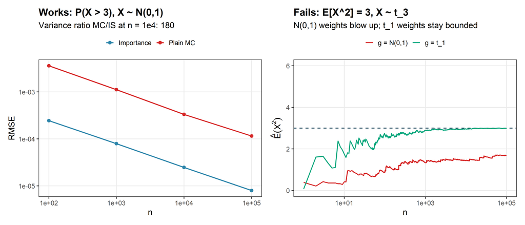

Left: estimating $P(X > 3)$ for a standard normal. A $\Normal(3,1)$ proposal concentrates draws where the integrand lives and beats plain MC by orders of magnitude. Right: estimating $\E[X^2]$ for $X \sim t_3$. A $\Normal(0,1)$ proposal has lighter tails, so the weights are unbounded and the running estimate never settles. A $t_1$ proposal has heavier tails and converges.

## What You Actually Do in Practice

1. **Choose $g$ with heavier tails than $f$.** If $g$ drops off faster than $f$, some weights will eventually dominate. There is no recovering from lighter tails.
2. **Look at the weights.** Plot the unnormalized weights and check for a few extreme values dwarfing the rest. This is the first and cheapest diagnostic.
3. **Effective sample size.** $n_{\text{eff}} = \frac{(\sum_i w_i)^2}{\sum_i w_i^2}$. When $n_{\text{eff}} \ll n$, a handful of particles carry all the weight and the estimate is unreliable.
4. **PSIS $\hat{k}$ as the diagnostic.** Fit a generalized Pareto to the largest weights; its shape estimate $\hat{k}$ reads off the tail. $\hat{k} < 0.5$: the weights have finite variance. $0.5 \leq \hat{k} < 0.7$: infinite variance, but the smoothed estimate is still usable. $\hat{k} \geq 0.7$: do not trust it, change $g$. We will see this again in the Bayesian block.

# Variance Reduction

## Variance Reduction: Overview

**Goal.** Reduce $\Var[\hat{I}]$ without increasing computational cost (much).

**Main Techniques.**

1. **Control Variates**: Use correlated auxiliary variable
2. **Antithetic Variables**: Introduce negative correlation
3. **Stratified Sampling**: Divide and conquer
4. **Rao-Blackwellization**: Use conditional expectations
5. **Common Random Numbers**: For comparisons

## Control Variates

**The Idea.** Use a correlated variable $Y$ with known $\E[Y] = \mu_Y$:
$$\hat{I}_{CV} = \hat{I} - c(\bar{Y} - \mu_Y)$$

**Optimal $c$.**
$$c^* = \frac{\Cov(h(X), Y)}{\Var(Y)}$$

Variance reduction:
$$\frac{\Var[\hat{I}_{CV}]}{\Var[\hat{I}]} = 1 - \rho^2_{h(X),Y}$$

The optimal coefficient $c^*$ is the slope of the regression of $h(X)$ on $Y$. The variance reduction equals the $R^2$ of that regression: the more $Y$ explains $h(X)$, the more variance you remove.

**Example.** Estimating $\E[e^X]$ where $X \sim \Normal(0,1)$: use $Y = X$ as control, $\E[Y] = 0$ known. High correlation.

## Control Variate Adjustment

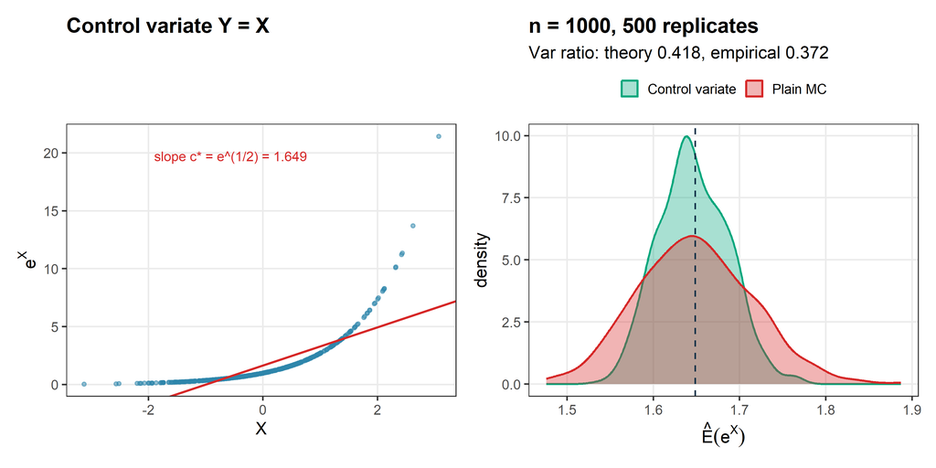

## Antithetic Variables

**The Idea.** Generate pairs $(X, X')$ with:

- Same marginal distribution
- Negative correlation

**Implementation.** For $U \sim \Uniform(0,1)$:

- Use both $U$ and $1-U$
- Transform both via $F^{-1}$

Estimate: $\hat{I}_{AV} = \frac{1}{2n}\sum_{i=1}^n [h(X_i) + h(X'_i)]$

## Antithetic Variables: Detailed Analysis

**Variance Reduction Formula.** For antithetic pairs $(X, X')$ with $X' = F^{-1}(1-U)$ when $X = F^{-1}(U)$:
$$\Var[\hat{I}_{AV}] = \frac{1}{2n}[\Var(h(X)) + \Cov(h(X), h(X'))]$$

**Reduction factor**: $\dfrac{\Var[\hat{I}_{AV}]}{\Var[\hat{I}_{MC}]} = \dfrac{1}{2}[1 + \rho_{h(X),h(X')}]$

The factor compares $n$ antithetic pairs with $n$ independent draws. A pair costs two evaluations of $h$, so it has to beat $1/2$ to pay for itself: it does when $h$ is monotone ($\rho < 0$), and it loses when $\rho > 0$, as for a U-shaped or oscillating $h$.

## Antithetic Variables: Example

**Example: $\E[e^X]$, $X \sim \Uniform(0,1)$.**

- $X' = 1 - X$ (perfect negative correlation)
- $\Cov(e^X, e^{1-X}) = e - (e-1)^2 \approx -0.234$
- $\Var(e^X) = (e^2-1)/2 - (e-1)^2 \approx 0.242$
- $\rho_{h(X),h(X')} \approx -0.968$
- **Reduction factor**: $\frac{1}{2}(1 - 0.968) = 0.016$

$e^X$ is nearly linear on $[0, 1]$, so this is close to the best case; the next slide gives the typical range.

## Antithetic Variables: Practical Gains

**When Antithetic Works Best.**

- $h$ is **monotonic**: $\rho < 0$
- Linear $h$ with symmetric $f$: perfect
  - $\rho = -1$
  - Reduction factor = 0
  - Zero variance.

**Typical reduction factors:**

- Monotonic $h$: 0.1–0.3
- Non-monotonic $h$: 0.4–0.6
- Worst case: $> 0.5$ (harmful)

## Stratified Sampling

**The Idea.**

1. Partition domain: $\mathcal{X} = \bigcup_{j=1}^k A_j$
2. Sample $n_j$ points from each $A_j$
3. Weight by $p_j = P(X \in A_j)$

**Estimate.**
$$\hat{I}_{SS} = \sum_{j=1}^k p_j \hat{I}_j$$
where $\hat{I}_j$ is the estimate from stratum $j$.

With $\sigma_j^2 = \Var[h(X) \mid X \in A_j]$ the within-stratum variance, the variance of a plain Monte Carlo draw splits into a within-strata part and a between-strata part. Stratified sampling removes the between-strata part, so the gain is larger when the stratum means $\mu_j$ differ widely; the split $n_j \propto p_j \sigma_j$ on the next slide is the optimal allocation.

## Stratified Sampling: Detailed Analysis

**Variance Reduction Formula.** With $k$ strata, proportions $p_j = P(X \in S_j)$, and $n_j$ samples from stratum $j$:
$$\Var[\hat{I}_{SS}] = \sum_{j=1}^k p_j^2 \frac{\sigma_j^2}{n_j}$$

**Proportional Allocation.** Set $n_j = n \cdot p_j$:
$$\Var[\hat{I}_{SS}] = \frac{1}{n}\sum_{j=1}^k p_j \sigma_j^2$$

Compare to basic MC:
$$\Var[\hat{I}_{MC}] = \frac{\sigma^2}{n} = \frac{1}{n}\left[\sum_{j=1}^k p_j \sigma_j^2 + \sum_{j=1}^k p_j(\mu_j - \mu)^2\right]$$

**Reduction** = between-strata variance.

**Optimal (Neyman) Allocation.** Set $n_j \propto p_j \sigma_j$:
$$\Var[\hat{I}_{SS}^{opt}] = \frac{1}{n}\left(\sum_{j=1}^k p_j \sigma_j\right)^2$$

**Example**: $h(x) = x^2$ on $[0,1]$ with 4 strata

- Basic MC: $\Var = 4/45 \approx 0.0889/n$
- Proportional: $\Var = 0.00686/n$, factor **0.077**
- Optimal: $\Var = 0.00524/n$, factor **0.059**

## Four Variance-Reduction Ideas, Four Roles

| Method | Exploits | Needs | Hurts when |
| --- | --- | --- | --- |
| Control Variates | Correlation with a known-mean auxiliary | Exact $\E[Y]$, estimable $\Cov$ | $Y$ is uncorrelated with $h(X)$ |
| Antithetic Variables | Monotonicity of $h$ | $F^{-1}$ or a pairing rule | $h$ is non-monotone ($\rho > 0$) |
| Stratified Sampling | Heterogeneity across strata | Computable $p_j$, pilot $\sigma_j$ | Strata means are equal |
| Importance Sampling | Concentration of $hf$ | Heavier tails than $f$ | $g$ has lighter tails (weight degeneracy) |

## Variance Reduction Comparison

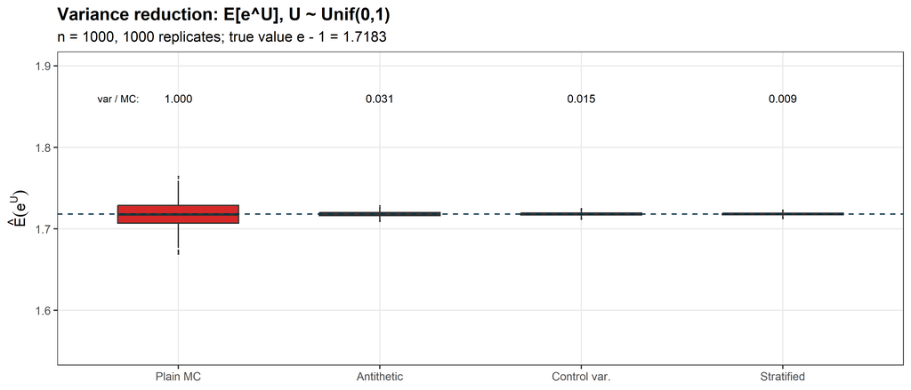

All four methods spend the same 1000 evaluations of $h$, so the antithetic ratio shown is $1 + \rho = 0.032$, twice the per-pair factor $\tfrac12(1+\rho) = 0.016$ quoted earlier; the control variate $Y = U$ ($\rho = 0.992$) and ten proportional strata do about as well on this near-linear integrand.

## The Ugly Truth

**What Textbooks Don’t Tell You.** Those beautiful variance reduction formulas assume we know things we don’t.

**The Setup Costs.**

- Stratified: Need pilot study to estimate $p_j$, $\sigma_j$
- Control Variates: Must know $\E[Y]$ exactly
- Importance Sampling: Finding good proposal is hard
- Antithetic: Only works if $h$ is monotonic

**Reality Check.** 10 strata, 1000 pilot samples, 10000 main samples:

- 10% overhead just for setup
- Need more than 10% variance reduction to break even
- Often don’t get it.

## When Classical Methods Fail

**Stratified Sampling Dies In:**

- High dimensions (curse of dimensionality)
- Complex distributions (can’t compute $P(X \in S_j)$)
- Black-box simulators (no access to internals)

**Importance Sampling Dies In:**

- High dimensions (weight degeneracy)
- Tail mismatch: proposal lighter than the target (infinite variance)
- Bad proposal choice (most of them)

**The Brutal Truth.** In practice, just using more samples often beats fancy variance reduction.

## PSIS

**Pareto Smoothed Importance Sampling.** The one method that actually works in practice.

**The Key Idea.** Extreme importance weights follow a Pareto distribution.

- Fit generalized Pareto to largest 20% of weights
- Replace extreme weights with smoothed values
- Get automatic reliability diagnostic ($\hat{k}$)

**The $\hat{k}$ Diagnostic.**

- $\hat{k} < 0.5$: Excellent, trust results
- $0.5 \leq \hat{k} < 0.7$: OK, use with caution
- $\hat{k} \geq 0.7$: Bad, don’t trust, recompute

## Why PSIS Dominates

**Where You’ll See It.**

- Stan (loo package)
- ArviZ (Python/R)
- Any modern Bayesian software

**The Killer App: LOO-CV from One MCMC Run.** Without PSIS: Run MCMC $n$ times (impossible). With PSIS: Run MCMC once, get LOO-CV for free.

But more on this when we formally enter the realms of Bayesian computing.

## What to Carry Out of the Room

- Ratio of uniforms replaces Accept-Reject’s proposal $g$ and bound $M$ with bounds on a 2D region, and handles unnormalized densities automatically.
- ARS builds and tightens its own envelope as it runs, for any log-concave target.
- Importance sampling is the centerpiece: keep every draw, weight by $f/g$, and the variance of the weighted average depends entirely on how well $g$ matches $|h|f$.
- The four variance-reduction techniques each exploit a different structural feature and each can backfire when the feature is absent.

The week’s punchline: once you move from generating samples to estimating integrals, the design problem shifts from “which draws do I keep?” to “which draws do I weight, and how?” Importance sampling is the bridge between the sampling methods of weeks 2–4 and the Bayesian computing machinery from week 10 on, and the $\hat{k}$ diagnostic tells you whether the bridge is holding.

Next week: the bootstrap. A different answer to “how do I estimate variability?”, one that replaces distributional assumptions with the empirical distribution.